# Práctica

```python
df= df[(df['Beds'] <= 10) & (df['Extra People'] <= 50) & (df['Minimum Nights'] <= 15) &
                 (df['Number of Reviews'] <= 200) & (df['Reviews per Month'] <= 9) & (df['bed_bath_rooms'] <= 12) &
                 (df['guests_extra_people'] <= 150) & (df['properties_review'] <= 1200)]
df.describe().T
```

|  | count | mean | std | min | 25% | 50% | 75% | max |
| --- | --- | --- | --- | --- | --- | --- | --- | --- |
| Neighbourhood | 72.0 | 30.750000 | 21.726695 | 0.000000 | 3.000000 | 39.000000 | 49.000000 | 59.000000 |
| Property Type | 72.0 | 1.347222 | 4.014620 | 0.000000 | 0.000000 | 0.000000 | 0.000000 | 16.000000 |
| Room Type | 72.0 | 0.041667 | 0.201229 | 0.000000 | 0.000000 | 0.000000 | 0.000000 | 1.000000 |
| Accommodates | 72.0 | 6.041667 | 2.346334 | 1.000000 | 4.000000 | 6.000000 | 8.000000 | 12.000000 |
| Bathrooms | 72.0 | 2.076389 | 0.573227 | 1.000000 | 2.000000 | 2.000000 | 2.500000 | 3.000000 |
| Bedrooms | 72.0 | 2.652778 | 0.966476 | 1.000000 | 2.000000 | 3.000000 | 3.000000 | 5.000000 |
| Beds | 72.0 | 4.069444 | 1.825688 | 1.000000 | 3.000000 | 4.000000 | 5.000000 | 8.000000 |
| Price | 72.0 | 228.861111 | 15.254928 | 205.000000 | 220.000000 | 226.000000 | 241.250000 | 250.000000 |
| Guests Included | 72.0 | 2.250000 | 1.805703 | 1.000000 | 1.000000 | 1.000000 | 4.000000 | 8.000000 |
| Extra People | 72.0 | 6.555556 | 9.198728 | 0.000000 | 0.000000 | 0.000000 | 15.000000 | 30.000000 |
| Minimum Nights | 72.0 | 2.861111 | 2.030094 | 1.000000 | 2.000000 | 3.000000 | 3.000000 | 15.000000 |
| Number of Reviews | 72.0 | 14.319444 | 21.001560 | 0.000000 | 1.000000 | 5.500000 | 19.250000 | 97.000000 |
| Cancellation Policy | 72.0 | 1.347222 | 0.841858 | 0.000000 | 1.000000 | 2.000000 | 2.000000 | 2.000000 |
| Reviews per Month | 72.0 | 1.324306 | 1.119431 | 0.020000 | 0.395000 | 1.270000 | 1.770000 | 5.000000 |
| antiguedad_host | 72.0 | 3.140791 | 1.775118 | 0.038356 | 1.415753 | 3.412329 | 4.564384 | 6.339726 |
| Properties_Count | 72.0 | 12.277778 | 18.730274 | 1.000000 | 1.000000 | 3.000000 | 11.500000 | 83.000000 |
| TV | 72.0 | 0.916667 | 0.278325 | 0.000000 | 1.000000 | 1.000000 | 1.000000 | 1.000000 |
| Air conditioning | 72.0 | 0.791667 | 0.408966 | 0.000000 | 1.000000 | 1.000000 | 1.000000 | 1.000000 |
| Wheelchair accessible | 72.0 | 0.097222 | 0.298339 | 0.000000 | 0.000000 | 0.000000 | 0.000000 | 1.000000 |
| Breakfast | 72.0 | 0.125000 | 0.333040 | 0.000000 | 0.000000 | 0.000000 | 0.000000 | 1.000000 |
| bed_bath_rooms | 72.0 | 5.687500 | 2.798940 | 1.000000 | 4.000000 | 5.000000 | 7.625000 | 12.000000 |
| guests_extra_people | 72.0 | 27.125000 | 42.974915 | 0.000000 | 0.000000 | 0.000000 | 40.000000 | 150.000000 |
| properties_review | 72.0 | 88.875000 | 168.237922 | 0.000000 | 3.000000 | 25.000000 | 91.500000 | 966.000000 |

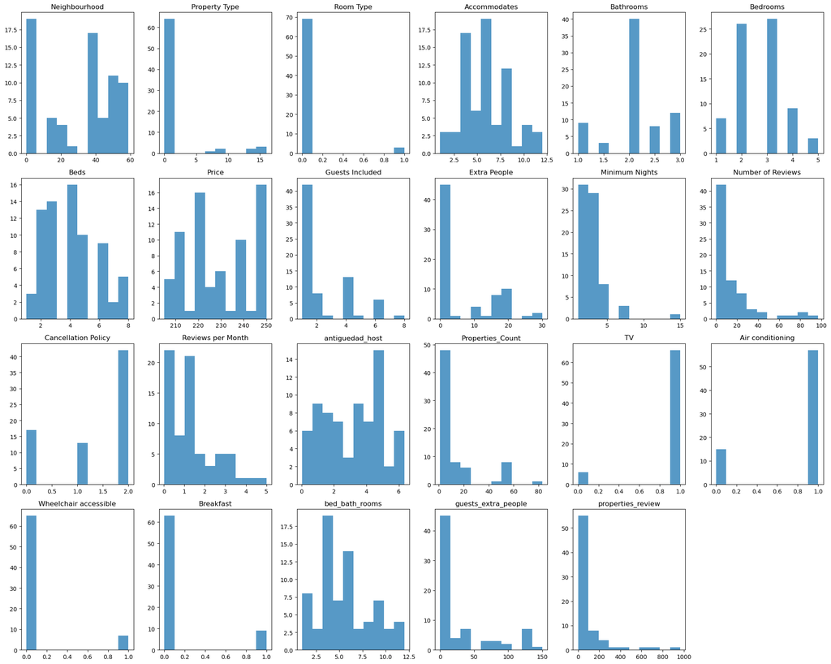

```python
# Pintamos de nuevo los histogramas para cada clase

plt.figure(figsize=(20,16))

columns_to_plot = df.columns.tolist()

num_plots = min(len(columns_to_plot), 24)

for i in range(num_plots):
    plt.subplot(4, 6, i + 1)
    column = columns_to_plot[i]
    plt.hist(df[column], density=0, alpha=0.75)
    plt.title(column)

plt.tight_layout()
plt.show()
```

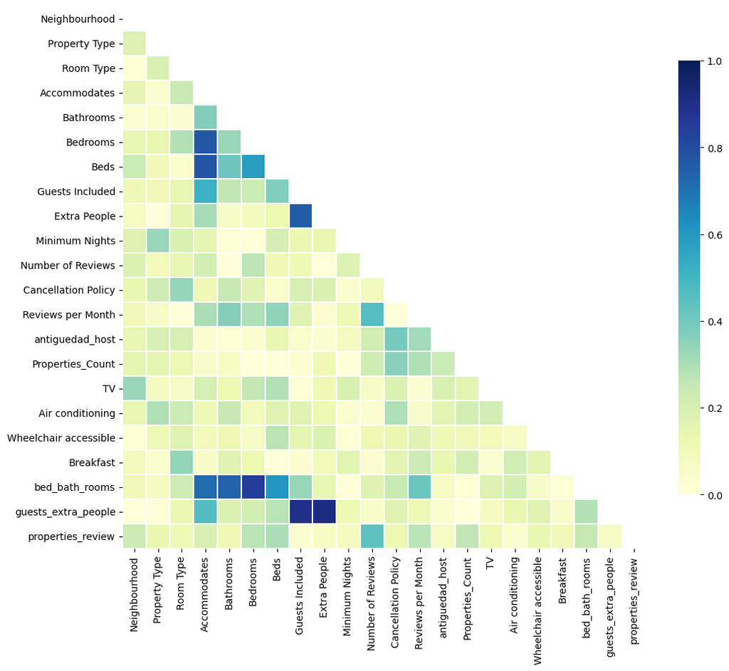

```python
# Veamos la matriz de correlación
import seaborn as sns

# Compute the correlation matrix
corr = np.abs(df.drop(['Price'], axis=1).corr())

# Generate a mask for the upper triangle
mask = np.zeros_like(corr, dtype=np.bool)
mask[np.triu_indices_from(mask)] = True

# Set up the matplotlib figure
f, ax = plt.subplots(figsize=(12, 10))

# Draw the heatmap with the mask and correct aspect ratio
sns.heatmap(corr, mask=mask,vmin = 0.0, vmax=1.0, center=0.5,
            linewidths=.1, cmap="YlGnBu", cbar_kws={"shrink": .8})

plt.show()
```

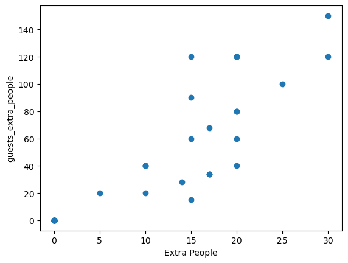

```python
# Parece que Extra People y Guests included tienen una correlación alta entre sí. Quizás debamos quitar Extra People, que
# puede ser redundante con guests_extra_people ya que es una variable compuesta

plt.scatter(df['Extra People'], df['guests_extra_people'])
plt.xlabel('Extra People')
plt.ylabel('guests_extra_people')
plt.show()

# Vamos a eliminar Extra People y quedarnos con la otra variable

df.drop(['Extra People'], axis = 1, inplace = True)
```

###### #

```python
######  Una vez observados los resultados de los modelos, puede haber relaciones que hemos obviado, además de algunas variables
# que no aportan valor y aumentan la complejidad.

# Vamos a eliminar esas variables
#variables_descartadas = ['Property Type', 'Minimum Nights', 'Cancellation Policy', 'Breakfast', 'TV', 'Wheelchair accessible', 'Air conditioning', 'Guests Included', 'properties_review']
variables_descartadas = ['Property Type', 'TV', 'Wheelchair accessible', 'Breakfast', 'Bathrooms', 'Cancellation Policy', 'Guests Included']
df.drop(variables_descartadas, axis = 1, inplace = True)
```

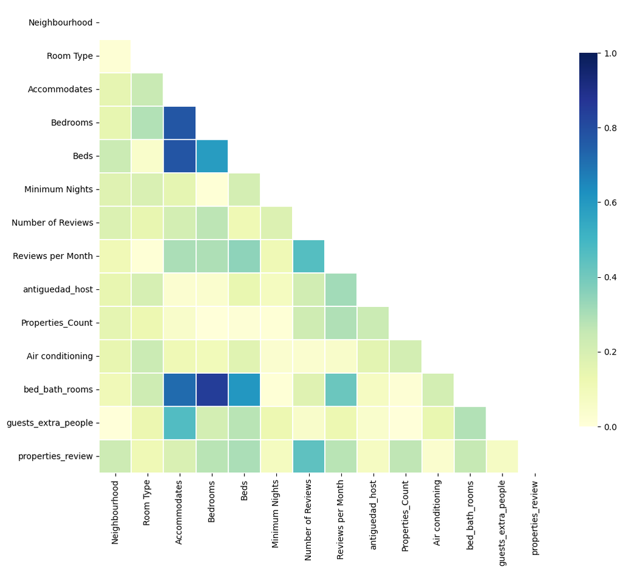

```python
# Veamos de nuevo la matriz de correlación

import seaborn as sns

# Compute the correlation matrix
corr = np.abs(df.drop(['Price'], axis=1).corr())

# Generate a mask for the upper triangle
mask = np.zeros_like(corr, dtype=np.bool)
mask[np.triu_indices_from(mask)] = True

# Set up the matplotlib figure
f, ax = plt.subplots(figsize=(12, 10))

# Draw the heatmap with the mask and correct aspect ratio
sns.heatmap(corr, mask=mask,vmin = 0.0, vmax=1.0, center=0.5,
            linewidths=.1, cmap="YlGnBu", cbar_kws={"shrink": .8})

plt.show()
```

```python
# RESUMEN DEL ANÁLISIS EXPLORATORIO

import pandas as pd
import numpy as np
from sklearn.preprocessing import LabelEncoder

# Cargo el df de train (no tiene las urls ya)
df = pd.read_csv('./train.csv', sep=';', decimal='.')

# Descartes iniciales en una primera exploración
descartes = ['ID', 'Scrape ID', 'Last Scraped', 'Name', 'Host Name', 'Host Listings Count', 'Host Total Listings Count', 'Calendar last Scraped', 'Notes', 'Host Acceptance Rate', 'Weekly Price', 'Monthly Price', 'Has Availability', 'License', 'Jurisdiction Names', 'Latitude', 'Longitude', 'Geolocation', 'Summary', 'Space', 'Description', 'Neighborhood Overview', 'Transit', 'Access', 'Interaction', 'House Rules', 'House Rules', 'Host About', 'Street', 'Neighbourhood Cleansed', 'Neighbourhood Group Cleansed', 'Maximum Nights', 'Calendar Updated', 'First Review', 'Last Review', 'City', 'State', 'Market', 'Smart Location', 'Country Code', 'Country', 'Availability 30', 'Availability 60', 'Availability 90', 'Availability 365', 'Square Feet', 'Security Deposit', 'Cleaning Fee', 'Calculated host listings count']
df.drop(descartes, axis = 1, inplace = True)

# La variable Experiences Offered parecía interesante, pero vemos que solo tenía valor None
df.drop('Experiences Offered', axis = 1, inplace = True)

# A partir de Host Since, creamos una variable que explica la antigüedad del host en AB&B, lo que podría tener significado en el precio
df['antiguedad_host'] = (pd.to_datetime(df['Host Since']).max() - pd.to_datetime(df['Host Since'])).dt.days / 365
df.drop('Host Since', axis = 1, inplace = True)

# Nuevos descartes tras analizar en profundidad los datos relacionados con Host y quedarnos con los considerados útiles
descartes2 = ['Host Location', 'Host Neighbourhood', 'Host Verifications', 'Host Response Time', 'Host Response Rate']
df.drop(descartes2, axis = 1, inplace = True)

# Podría ser significante la cantidad de propiedades que tiene cada propietario. Creamos una variable que lo calcula y ya
# podemos eliminar Host ID
df['Properties_Count'] = df['Host ID'].map(df['Host ID'].value_counts())
df.drop('Host ID', axis = 1, inplace = True)

# Observamos que Neighbourhood y Zipcode tienen bastantes valores nulos, pero si las ponemos en relación, podemos completar los
# barrios mediante los zipcodes, ya que cada barrio siempre tendrá unos zipcodes concretos.
# Creamos una lista que relaciona cada zipcode con su barrio, y de este modo, comprobando que no hay ninguna fila que tuviera
# tanto zipcode como Neighbourhood nulo, podemos completar los barrios que faltan gracias a su zipcode.
# Tras esto, eliminamos Zipcode que ya no nos sirve
barrios_zipcodes = df.dropna(subset=['Neighbourhood', 'Zipcode']).groupby('Neighbourhood')['Zipcode'].apply(list).to_dict()
df['Neighbourhood'] = df.apply(lambda row: ', '.join(barrios_zipcodes.get(row['Zipcode'], [])) if pd.isnull(row['Neighbourhood']) else row['Neighbourhood'], axis=1)
df.drop('Zipcode', axis = 1, inplace = True)

# En las Features, hay algunas opciones que podrían tener alguna relevancia, como que el Host esté verificado. Vamos
#  a separar aquellos en los que el host está verificado y los que no
df['HostVerified'] = df['Features'].str.contains('Host Identity Verified')
df['HostVerified'] = df['HostVerified'].notna().astype(int)

# En Amenities, vemos que existen variables que pueden ser relevantes. Nos quedaremos con TV, Wireless Internet, Air conditioning, Kitchen,
# Wheelchair accessible, Breakfast. Crearemos una variable binaria para cada una:
df['TV'] = df['Amenities'].str.contains('TV')
df['TV'] = df['TV'].fillna(False).astype(int)

df['Wireless Internet'] = df['Amenities'].str.contains('Wireless Internet')
df['Wireless Internet'] = df['Wireless Internet'].fillna(False).astype(int)

df['Air conditioning'] = df['Amenities'].str.contains('Air conditioning')
df['Air conditioning'] = df['Air conditioning'].fillna(False).astype(int)

df['Kitchen'] = df['Amenities'].str.contains('Kitchen')
df['Kitchen'] = df['Kitchen'].fillna(False).astype(int)

df['Wheelchair accessible'] = df['Amenities'].str.contains('Wheelchair accessible')
df['Wheelchair accessible'] = df['Wheelchair accessible'].fillna(False).astype(int)

df['Breakfast'] = df['Amenities'].str.contains('Breakfast')
df['Breakfast'] = df['Breakfast'].fillna(False).astype(int)

# Elimino Amenities tras sacar la información interesante
df.drop(['Amenities', 'Features'], axis = 1, inplace = True)

# Utilizamos LabelEncoder para codificar las variables no numéricas que nos interesan:
le_Neighbourhood = LabelEncoder()
le_Property = LabelEncoder()
le_Room = LabelEncoder()
le_Bed = LabelEncoder()
le_Cancellation = LabelEncoder()

df['Neighbourhood'] = le_Neighbourhood.fit_transform(df['Neighbourhood'])
df['Property Type'] = le_Property.fit_transform(df['Property Type'])
df['Room Type'] = le_Room.fit_transform(df['Room Type'])
df['Bed Type'] = le_Bed.fit_transform(df['Bed Type'])
df['Cancellation Policy'] = le_Cancellation.fit_transform(df['Cancellation Policy'])

# Tras analizar el grupo de variables Review, dropeamos las que no nos aportan valor (además tienen muchos nulos)
df.drop(['Review Scores Rating', 'Review Scores Accuracy', 'Review Scores Cleanliness', 'Review Scores Checkin', 'Review Scores Communication', 'Review Scores Location', 'Review Scores Value'], axis = 1, inplace = True)

# Reviews per month parece podría tener alguna razón de ser, pero tiene nulos. En este caso podría ser una opción imputar la mediana a esos valores,
# ya que es menos sensible a los valores extremos
df['Reviews per Month'] = df['Reviews per Month'].fillna(df['Reviews per Month'].median())

# Ahora, vemos que hay unos pocos valores en el dataset que tienen valores nulos. En concreto, son 70 de los 9244 iniciales,
# así que los vamos a eliminar
df = df.dropna()

# Tras una exploración visual a los histogramas de cada variable y ver los value counts de algunas que parecían tener poca
# o ninguna varieda en sus datos, eliminamos Bed Type, donde casi todos sus valores eran iguales y HostVerified que todos eran 1
df.drop(['Bed Type', 'HostVerified', 'Wireless Internet', 'Kitchen'], axis = 1, inplace = True)

# Revisando los histogramas y value_counts, parece que podríamos generar nuevas variables que pueden tener relación
df['bed_bath_rooms']   = df['Bedrooms']*df['Bathrooms']
df['guests_extra_people']   = df['Guests Included']*df['Extra People']
df['properties_review']   = df['Properties_Count']*df['Number of Reviews']

# Tras revisar los histogramas, cuartiles y conteos, vamos a eliminar algunos outlayers (<2% entre la suma de todos)

df= df[(df['Beds'] <= 11) & (df['Extra People'] <= 100) & (df['Minimum Nights'] <= 28) &
                 (df['Number of Reviews'] <= 200) & (df['Reviews per Month'] <= 10) & (df['bed_bath_rooms'] <= 36) &
                 (df['guests_extra_people'] <= 300) & (df['properties_review'] <= 1500)]

# Para el Price, vamos a buscar outliers de una forma bastante más objetiva,
# Para no eliminar demasiados valores, consideraremos aquellos que estén 2.5 veces sobre el rango intercuantílico.
# Buscaremos solo por arriba.
q1 = df['Price'].quantile(0.25)
q3 = df['Price'].quantile(0.75)
iqr = q3 - q1

upper_bound = q3 + 2.5 * iqr

pd.set_option('display.max_rows', None)

df = df[(df['Price'] < upper_bound)]


# Finalmente, tras observar la matriz de correlación, decidimos eliminar también Extra People, al tener una alta correlación con
# guests_extra_people

df.drop(['Extra People'], axis = 1, inplace = True)

######  Una vez observados los resultados de los modelos, puede haber relaciones que hemos obviado, además de algunas variables
# que no aportan valor y aumentan la complejidad.

# Vamos a eliminar esas variables
#variables_descartadas = ['Property Type', 'Minimum Nights', 'Cancellation Policy', 'Breakfast', 'TV', 'Wheelchair accessible', 'Air conditioning', 'Guests Included', 'properties_review']
variables_descartadas = ['Property Type', 'TV', 'Wheelchair accessible', 'Breakfast', 'Bathrooms', 'Cancellation Policy', 'Guests Included']
df.drop(variables_descartadas, axis = 1, inplace = True)


print(df.shape)
df.head()
```

```
(8780, 15)
```

|  | Neighbourhood | Room Type | Accommodates | Bedrooms | Beds | Price | Minimum Nights | Number of Reviews | Reviews per Month | antiguedad_host | Properties_Count | Air conditioning | bed_bath_rooms | guests_extra_people | properties_review |
| --- | --- | --- | --- | --- | --- | --- | --- | --- | --- | --- | --- | --- | --- | --- | --- |
| 0 | 0 | 0 | 4 | 1.0 | 2.0 | 60.0 | 2 | 53 | 3.05 | 1.463014 | 1 | 1 | 1.0 | 0 | 53 |
| 1 | 21 | 0 | 3 | 0.0 | 2.0 | 45.0 | 1 | 49 | 2.37 | 1.769863 | 1 | 0 | 0.0 | 20 | 49 |
| 2 | 5 | 1 | 2 | 1.0 | 1.0 | 20.0 | 2 | 3 | 3.00 | 0.336986 | 4 | 0 | 2.0 | 0 | 12 |
| 4 | 0 | 0 | 5 | 3.0 | 5.0 | 95.0 | 1 | 34 | 1.87 | 1.671233 | 1 | 1 | 3.0 | 80 | 34 |
| 5 | 0 | 1 | 3 | 1.0 | 2.0 | 50.0 | 2 | 1 | 0.18 | 0.610959 | 1 | 0 | 2.0 | 36 | 1 |

[output not shown]

[output cut: 176 more lines]

[output not shown]

```python
# APLICO EL ANÁLISIS A TEST

# Cargo el df de train (no tiene las urls ya)
df_test = pd.read_csv('./test.csv', sep=';', decimal='.')

# Descartes iniciales en una primera exploración
descartes = ['ID', 'Scrape ID', 'Last Scraped', 'Name', 'Host Name', 'Host Listings Count', 'Host Total Listings Count', 'Calendar last Scraped', 'Notes', 'Host Acceptance Rate', 'Weekly Price', 'Monthly Price', 'Has Availability', 'License', 'Jurisdiction Names', 'Latitude', 'Longitude', 'Geolocation', 'Summary', 'Space', 'Description', 'Neighborhood Overview', 'Transit', 'Access', 'Interaction', 'House Rules', 'House Rules', 'Host About', 'Street', 'Neighbourhood Cleansed', 'Neighbourhood Group Cleansed', 'Maximum Nights', 'Calendar Updated', 'First Review', 'Last Review', 'City', 'State', 'Market', 'Smart Location', 'Country Code', 'Country', 'Availability 30', 'Availability 60', 'Availability 90', 'Availability 365', 'Square Feet', 'Security Deposit', 'Cleaning Fee', 'Calculated host listings count']
df_test.drop(descartes, axis = 1, inplace = True)

# La variable Experiences Offered parecía interesante, pero vemos que solo tenía valor None
df_test.drop('Experiences Offered', axis = 1, inplace = True)

# A partir de Host Since, creamos una variable que explica la antigüedad del host en AB&B, lo que podría tener significado en el precio
df_test['antiguedad_host'] = (pd.to_datetime(df_test['Host Since']).max() - pd.to_datetime(df_test['Host Since'])).dt.days / 365
df_test.drop('Host Since', axis = 1, inplace = True)

# Nuevos descartes tras analizar en profundidad los datos relacionados con Host y quedarnos con los considerados útiles
descartes2 = ['Host Location', 'Host Neighbourhood', 'Host Verifications', 'Host Response Time', 'Host Response Rate']
df_test.drop(descartes2, axis = 1, inplace = True)

# Podría ser significante la cantidad de propiedades que tiene cada propietario. Creamos una variable que lo calcula y ya
# podemos eliminar Host ID
df_test['Properties_Count'] = df_test['Host ID'].map(df_test['Host ID'].value_counts())
df_test.drop('Host ID', axis = 1, inplace = True)

# Observamos que Neighbourhood y Zipcode tienen bastantes valores nulos, pero si las ponemos en relación, podemos completar los
# barrios mediante los zipcodes, ya que cada barrio siempre tendrá unos zipcodes concretos.
# Creamos una lista que relaciona cada zipcode con su barrio, y de este modo, comprobando que no hay ninguna fila que tuviera
# tanto zipcode como Neighbourhood nulo, podemos completar los barrios que faltan gracias a su zipcode.
# Tras esto, eliminamos Zipcode que ya no nos sirve
barrios_zipcodes = df_test.dropna(subset=['Neighbourhood', 'Zipcode']).groupby('Neighbourhood')['Zipcode'].apply(list).to_dict()
df_test['Neighbourhood'] = df_test.apply(lambda row: ', '.join(barrios_zipcodes.get(row['Zipcode'], [])) if pd.isnull(row['Neighbourhood']) else row['Neighbourhood'], axis=1)
df_test.drop('Zipcode', axis = 1, inplace = True)

# En las Features, hay algunas opciones que podrían tener alguna relevancia, como que el Host esté verificado. Vamos
#  a separar aquellos en los que el host está verificado y los que no
df_test['HostVerified'] = df_test['Features'].str.contains('Host Identity Verified')
df_test['HostVerified'] = df_test['HostVerified'].notna().astype(int)

# En Amenities, vemos que existen variables que pueden ser relevantes. Nos quedaremos con TV, Wireless Internet, Air conditioning, Kitchen,
# Wheelchair accessible, Breakfast. Crearemos una variable binaria para cada una:
df_test['TV'] = df_test['Amenities'].str.contains('TV')
df_test['TV'] = df_test['TV'].fillna(False).astype(int)

df_test['Wireless Internet'] = df_test['Amenities'].str.contains('Wireless Internet')
df_test['Wireless Internet'] = df_test['Wireless Internet'].fillna(False).astype(int)

df_test['Air conditioning'] = df_test['Amenities'].str.contains('Air conditioning')
df_test['Air conditioning'] = df_test['Air conditioning'].fillna(False).astype(int)

df_test['Kitchen'] = df_test['Amenities'].str.contains('Kitchen')
df_test['Kitchen'] = df_test['Kitchen'].fillna(False).astype(int)

df_test['Wheelchair accessible'] = df_test['Amenities'].str.contains('Wheelchair accessible')
df_test['Wheelchair accessible'] = df_test['Wheelchair accessible'].fillna(False).astype(int)

df_test['Breakfast'] = df_test['Amenities'].str.contains('Breakfast')
df_test['Breakfast'] = df_test['Breakfast'].fillna(False).astype(int)

# Elimino Amenities tras sacar la información interesante
df_test.drop(['Amenities', 'Features'], axis = 1, inplace = True)

# Utilizamos LabelEncoder para codificar las variables no numéricas que nos interesan:
le_Neighbourhood = LabelEncoder()
le_Property = LabelEncoder()
le_Room = LabelEncoder()
le_Bed = LabelEncoder()
le_Cancellation = LabelEncoder()

df_test['Neighbourhood'] = le_Neighbourhood.fit_transform(df_test['Neighbourhood'])
df_test['Property Type'] = le_Property.fit_transform(df_test['Property Type'])
df_test['Room Type'] = le_Room.fit_transform(df_test['Room Type'])
df_test['Bed Type'] = le_Bed.fit_transform(df_test['Bed Type'])
df_test['Cancellation Policy'] = le_Cancellation.fit_transform(df_test['Cancellation Policy'])

# Tras analizar el grupo de variables Review, dropeamos las que no nos aportan valor (además tienen muchos nulos)
df_test.drop(['Review Scores Rating', 'Review Scores Accuracy', 'Review Scores Cleanliness', 'Review Scores Checkin', 'Review Scores Communication', 'Review Scores Location', 'Review Scores Value'], axis = 1, inplace = True)

# Reviews per month parece podría tener alguna razón de ser, pero tiene nulos. En este caso podría ser una opción imputar la mediana a esos valores,
# ya que es menos sensible a los valores extremos
df_test['Reviews per Month'] = df_test['Reviews per Month'].fillna(df_test['Reviews per Month'].median())

# Ahora, vemos que hay unos pocos valores en el dataset que tienen valores nulos. En concreto, son 70 de los 9244 iniciales,
# así que los vamos a eliminar
df_test = df_test.dropna()

# Tras una exploración visual a los histogramas de cada variable y ver los value counts de algunas que parecían tener poca
# o ninguna varieda en sus datos, eliminamos Bed Type, donde casi todos sus valores eran iguales y HostVerified que todos eran 1
df_test.drop(['Bed Type', 'HostVerified', 'Wireless Internet', 'Kitchen'], axis = 1, inplace = True)

# Revisando los histogramas y value_counts, parece que podríamos generar una nueva variable que pueden tener relación
df_test['bed_bath_rooms']   = df_test['Bedrooms']*df_test['Bathrooms']
df_test['guests_extra_people']   = df_test['Guests Included']*df_test['Extra People']
df_test['properties_review']   = df_test['Properties_Count']*df_test['Number of Reviews']

# Tras revisar los histogramas, cuartiles y conteos, vamos a eliminar algunos outlayers (<2% entre la suma de todos)
df_test= df_test[(df_test['Beds'] <= 11) & (df_test['Extra People'] <= 100) & (df_test['Minimum Nights'] <= 28) &
                 (df_test['Number of Reviews'] <= 200) & (df_test['Reviews per Month'] <= 10) & (df_test['bed_bath_rooms'] <= 36) &
                 (df_test['guests_extra_people'] <= 300) & (df_test['properties_review'] <= 1500)]

# Para el Price, vamos a buscar outliers de una forma bastante más objetiva,
# Para no eliminar demasiados valores, consideraremos aquellos que estén 2.5 veces sobre el rango intercuantílico.
# Buscaremos solo por arriba.
q1 = df_test['Price'].quantile(0.25)
q3 = df_test['Price'].quantile(0.75)
iqr = q3 - q1

upper_bound = q3 + 2.5 * iqr

pd.set_option('display.max_rows', None)

df_test = df_test[(df_test['Price'] < upper_bound)]

# Finalmente, tras observar la matriz de correlación, decidimos eliminar también Extra People, al tener una alta correlación con
# guests_extra_people

df_test.drop(['Extra People'], axis = 1, inplace = True)


######  Una vez observados los resultados de los modelos, puede haber relaciones que hemos obviado, además de algunas variables
# que no aportan valor y aumentan la complejidad.

# Vamos a eliminar esas variables
#variables_descartadas = ['Property Type', 'Minimum Nights', 'Cancellation Policy', 'Breakfast', 'TV', 'Wheelchair accessible', 'Air conditioning', 'Guests Included', 'properties_review']
variables_descartadas = ['Property Type', 'TV', 'Wheelchair accessible', 'Breakfast', 'Bathrooms', 'Cancellation Policy', 'Guests Included']
df_test.drop(variables_descartadas, axis = 1, inplace = True)


print(df_test.shape)
df_test.head()
```

```
(3761, 15)
```

|  | Neighbourhood | Room Type | Accommodates | Bedrooms | Beds | Price | Minimum Nights | Number of Reviews | Reviews per Month | antiguedad_host | Properties_Count | Air conditioning | bed_bath_rooms | guests_extra_people | properties_review |
| --- | --- | --- | --- | --- | --- | --- | --- | --- | --- | --- | --- | --- | --- | --- | --- |
| 0 | 0 | 0 | 4 | 1.0 | 2.0 | 163.0 | 3 | 0 | 1.27 | 0.712329 | 4 | 1 | 1.0 | 0 | 0 |
| 1 | 0 | 1 | 2 | 1.0 | 1.0 | 40.0 | 1 | 0 | 1.27 | 1.419178 | 1 | 0 | 1.0 | 10 | 0 |
| 2 | 0 | 0 | 4 | 1.0 | 2.0 | 55.0 | 2 | 12 | 3.21 | 0.347945 | 1 | 0 | 1.0 | 14 | 12 |
| 3 | 56 | 0 | 4 | 0.0 | 2.0 | 65.0 | 1 | 87 | 3.09 | 5.386301 | 5 | 1 | 0.0 | 30 | 435 |
| 4 | 0 | 1 | 2 | 1.0 | 1.0 | 15.0 | 1 | 3 | 0.99 | 0.430137 | 1 | 0 | 2.0 | 15 | 3 |

```python
# Preparamos los datos

from sklearn.preprocessing import StandardScaler
from sklearn.model_selection import train_test_split
import matplotlib.pyplot as plt

features = df.columns.drop(['Price'])
X = df[features].values
y = df['Price'].values

print('Filas, Columnas', X.shape)
```

```
Filas, Columnas (8780, 14)
```

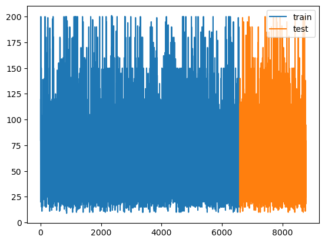

```python
scaler = StandardScaler()
X_scaled = scaler.fit_transform(X)


X_train, X_test, y_train, y_test = train_test_split(X_scaled, y, test_size = 0.25, random_state = 0)

plt.plot(range(0,len(y_train)),y_train, label='train')
plt.plot(range(len(y_train),len(y)),y_test,label='test')
plt.legend()
plt.show()
```

```
best mean cross-validation score: 0.570
best parameters: {'alpha': 100.0}
```

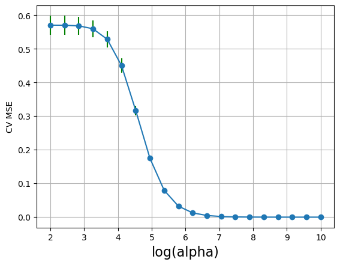

```python
# Vamos a entrenar en primer lugar un algoritmo de regresión lineal

# Comenzaremos implementando Ridge

from sklearn.linear_model import Ridge
from sklearn.model_selection import GridSearchCV

# Calcular valor óptimo de alpha

alpha_vector = np.logspace(2, 10, 20)
param_grid = {'alpha': alpha_vector}

grid = GridSearchCV(Ridge(), param_grid = param_grid, cv = 10)
grid.fit(X_train, y_train)


print("best mean cross-validation score: {:.3f}".format(grid.best_score_))
print("best parameters: {}".format(grid.best_params_))

scores = grid.cv_results_['mean_test_score']
std_scores = grid.cv_results_['std_test_score']
plt.errorbar(np.log10(alpha_vector),scores,yerr=std_scores, fmt='o-',ecolor='g')
plt.xlabel('log(alpha)',fontsize=16)
plt.ylabel('CV MSE')
plt.grid()
plt.show()
```

```python
# Ahora entrenamos el modelo con el valor de alpha óptimo de Cross Validation y vemos los coeficientes

best_alpha = grid.best_params_['alpha']
rm = Ridge(alpha = best_alpha).fit(X_train, y_train)

coefficient_names = dict(zip(features, rm.coef_))

for feature, coefficient in coefficient_names.items():
    print(f"{feature}: {coefficient}")
```

```
Neighbourhood: 2.2266249789966936
Room Type: -14.418396370714781
Accommodates: 7.1027135992758526
Bedrooms: 3.605899138372222
Beds: -0.38088337423127433
Minimum Nights: -1.4168552730767956
Number of Reviews: -1.8951810066304462
Reviews per Month: -1.9086799942000403
antiguedad_host: 0.4397828290859116
Properties_Count: 2.822248166930639
Air conditioning: 5.274473781261734
bed_bath_rooms: 6.065732017779847
guests_extra_people: 1.7943359278853765
properties_review: -0.6700445510372889
```

```
MSE train: 587.756
MSE test: 548.700
R2 train: 0.572
R2 test: 0.587
```

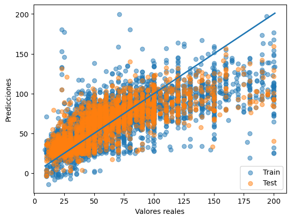

```python
from sklearn.metrics import mean_squared_error, r2_score

y_train_pred = rm.predict(X_train)
y_test_pred = rm.predict(X_test)

mse_train = mean_squared_error(y_train, y_train_pred)
mse_test = mean_squared_error(y_test, y_test_pred)

r2_train = r2_score(y_train, y_train_pred)
r2_test = r2_score(y_test, y_test_pred)

print("MSE train: {:.3f}".format(mse_train))
print("MSE test: {:.3f}".format(mse_test))
print("R2 train: {:.3f}".format(r2_train))
print("R2 test: {:.3f}".format(r2_test))

plt.scatter(y_train, y_train_pred, label = 'Train', alpha = 0.5)
plt.scatter(y_test, y_test_pred, label = 'Test', alpha = 0.5)

plt.plot([min(y_train), max(y_train)], [min(y_train), max(y_train)], lw=2)

plt.xlabel('Valores reales')
plt.ylabel('Predicciones')

plt.legend()
plt.show()
```

```
best mean cross-validation score: -591.240
best parameters: {'alpha': 0.12742749857031335}
```

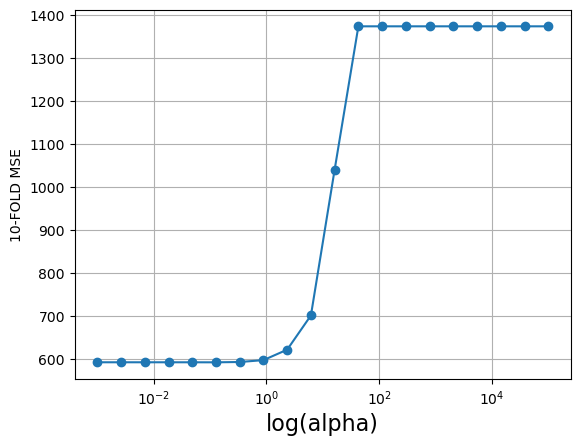

```python
# Veamos con Lasso

from sklearn.linear_model import Lasso

# Calcular valor óptimo de alpha

alpha_vector = np.logspace(-3, 5, 20)
param_grid = {'alpha': alpha_vector}

grid = GridSearchCV(Lasso(), scoring = 'neg_mean_squared_error', param_grid = param_grid, cv = 10)
grid.fit(X_train, y_train)


print("best mean cross-validation score: {:.3f}".format(grid.best_score_))
print("best parameters: {}".format(grid.best_params_))

scores = -1*np.array(grid.cv_results_['mean_test_score'])
plt.semilogx(alpha_vector, scores, '-o')
plt.xlabel('log(alpha)',fontsize=16)
plt.ylabel('10-FOLD MSE')
plt.grid()
plt.show()
```

```
Neighbourhood: 2.2266249789966936
Room Type: -14.418396370714781
Accommodates: 7.1027135992758526
Bedrooms: 3.605899138372222
Beds: -0.38088337423127433
Minimum Nights: -1.4168552730767956
Number of Reviews: -1.8951810066304462
Reviews per Month: -1.9086799942000403
antiguedad_host: 0.4397828290859116
Properties_Count: 2.822248166930639
Air conditioning: 5.274473781261734
bed_bath_rooms: 6.065732017779847
guests_extra_people: 1.7943359278853765
properties_review: -0.6700445510372889

MSE Lasso train: 587.943
MSE Lasso test: 548.448
R2 Lasso train: 0.572
R2 Lasso test: 0.587
```

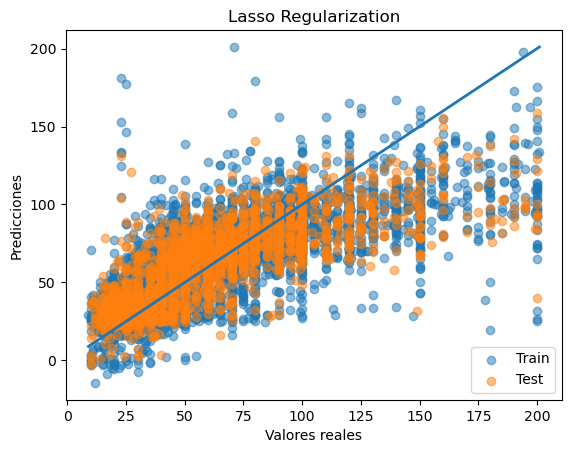

```python
best_alpha = grid.best_params_['alpha']

lasso = Lasso(alpha = best_alpha).fit(X_train, y_train)

coefficient_names = dict(zip(features, rm.coef_))

for feature, coefficient in coefficient_names.items():
    print(f"{feature}: {coefficient}")



y_train_pred = lasso.predict(X_train)
y_test_pred = lasso.predict(X_test)

mse_train = mean_squared_error(y_train, y_train_pred)
mse_test = mean_squared_error(y_test, y_test_pred)

r2_train = r2_score(y_train, y_train_pred)
r2_test = r2_score(y_test, y_test_pred)

print("")
print("MSE Lasso train: {:.3f}".format(mse_train))
print("MSE Lasso test: {:.3f}".format(mse_test))
print("R2 Lasso train: {:.3f}".format(r2_train))
print("R2 Lasso test: {:.3f}".format(r2_test))

plt.scatter(y_train, y_train_pred, label = 'Train', alpha = 0.5)
plt.scatter(y_test, y_test_pred, label = 'Test', alpha = 0.5)
plt.title("Lasso Regularization")

plt.plot([min(y_train), max(y_train)], [min(y_train), max(y_train)], lw=2)

plt.xlabel('Valores reales')
plt.ylabel('Predicciones')

plt.legend()
plt.show()
```

Vamos a estudiar más de cerca las variables que tienen coeficientes entre (-1, 1), cercanos a 0, comparando con diferentes modelos. En concreto nos están diciendo que Beds es muy poco significativa. También property reviews tiene poco peso, pero veamos con los demás métodos

```
best mean cross-validation score: 0.671
best parameters: {'max_depth': 14, 'n_estimators': 1000}
```

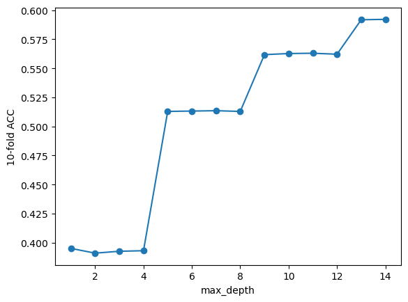

```python
# Vamos a trabajar ahora con Random Forest

from sklearn.ensemble import RandomForestRegressor

# Grid search
maxDepth = range(1, 15)
n_estimators = [500, 1000, 1500, 2000]
tuned_parameters = {'max_depth': maxDepth, 'n_estimators': n_estimators}
#tuned_parameters = {'max_depth': maxDepth}

grid = GridSearchCV(RandomForestRegressor(random_state = 0, max_features ='sqrt'), param_grid = tuned_parameters, cv = 5)
grid.fit(X_train, y_train)

print("best mean cross-validation score: {:.3f}".format(grid.best_score_))
print("best parameters: {}".format(grid.best_params_))

scores = np.array(grid.cv_results_['mean_test_score'][:len(maxDepth)])
plt.plot(maxDepth,scores,'-o')
plt.xlabel('max_depth')
plt.ylabel('10-fold ACC')

plt.show()
```

```python
# best n_estimators = 14
# best max_depth = 12
# Vamos a bajar ya que parece que hay overfitting
#maxDepthOptimo = grid.best_params_['max_depth']
maxDepthOptimo = 6

n_estimatorsOptimo = grid.best_params_['n_estimators']
rf = RandomForestRegressor(max_depth = maxDepthOptimo, n_estimators = n_estimatorsOptimo , max_features='sqrt').fit(X_train, y_train)
# Bajamos a 6 porque parece que con max_depth hay bastante overfitting

print("Train: ",rf.score(X_train,y_train))
print("Test: ",rf.score(X_test,y_test))
```

```
Train:  0.6609891228963838
Test:  0.6359855545554178
```

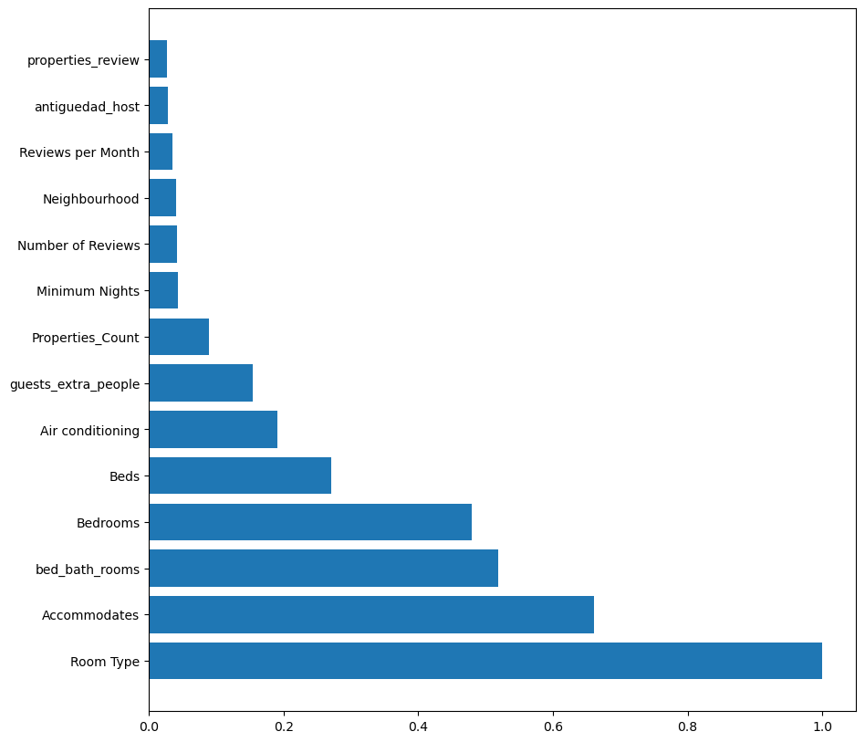

```python
importances = rf.feature_importances_
importances = importances / np.max(importances)

indices = np.argsort(importances)[::-1]

plt.figure(figsize=(10,10))
plt.barh(range(X_train.shape[1]), importances[indices])
plt.yticks(range(X_train.shape[1]), features[indices])
plt.show()
```

```python
# Inicialmente realizamos aquí una selección de características para tratar de mejorar el modelo, pero como no estaba mejorando,
# prescindimos de ella y probaremos ahora con Boosted Trees
```

```python
# Vamos a trabajar con Boosted Trees

from sklearn.ensemble import GradientBoostingRegressor

Niterations = [100, 200, 300, 500]
learningRate = [0.1, 0.05, 0.01]
maxDepth = 10
param_grid = {'n_estimators': Niterations, 'learning_rate': learningRate}

grid = GridSearchCV(GradientBoostingRegressor(random_state = 0, max_depth = maxDepth), param_grid = param_grid, cv = 5)
grid.fit(X_train, y_train)

print("best mean cross-validation score: {:.3f}".format(grid.best_score_))
print("best parameters: {}".format(grid.best_params_))
```

```
best mean cross-validation score: 0.646
best parameters: {'learning_rate': 0.05, 'n_estimators': 200}
```

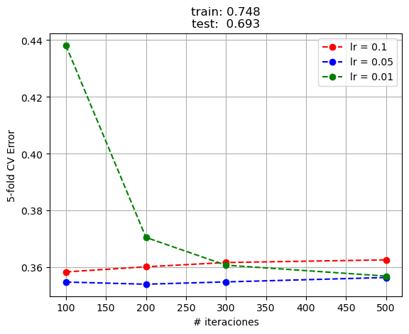

```python
# best lr 0.05
# best n estimators: 200
lrOptimo = grid.best_params_['learning_rate']
neOptimo = grid.best_params_['n_estimators']

# Tenemos que bajar max_depth para evitar el overfitting. Aplicamos algo de regularización alpha
bt = GradientBoostingRegressor(random_state = 0, max_depth = 4, learning_rate = lrOptimo, n_estimators = neOptimo,
                              alpha=0.5)
bt.fit(X_train, y_train)

error = 1-grid.cv_results_['mean_test_score'].reshape(len(learningRate), len(Niterations))
colors = ['r','b','g','k','m']

for i, lr in enumerate(learningRate):
    plt.plot(Niterations, error[i,:],colors[i] + '--o', label = 'lr = %g'%lr)

plt.legend()
plt.xlabel('# iteraciones')
plt.ylabel('5-fold CV Error')
plt.title('train: %0.3f\ntest:  %0.3f'%(bt.score(X_train,y_train),bt.score(X_test,y_test)))
plt.grid()
plt.show()
```

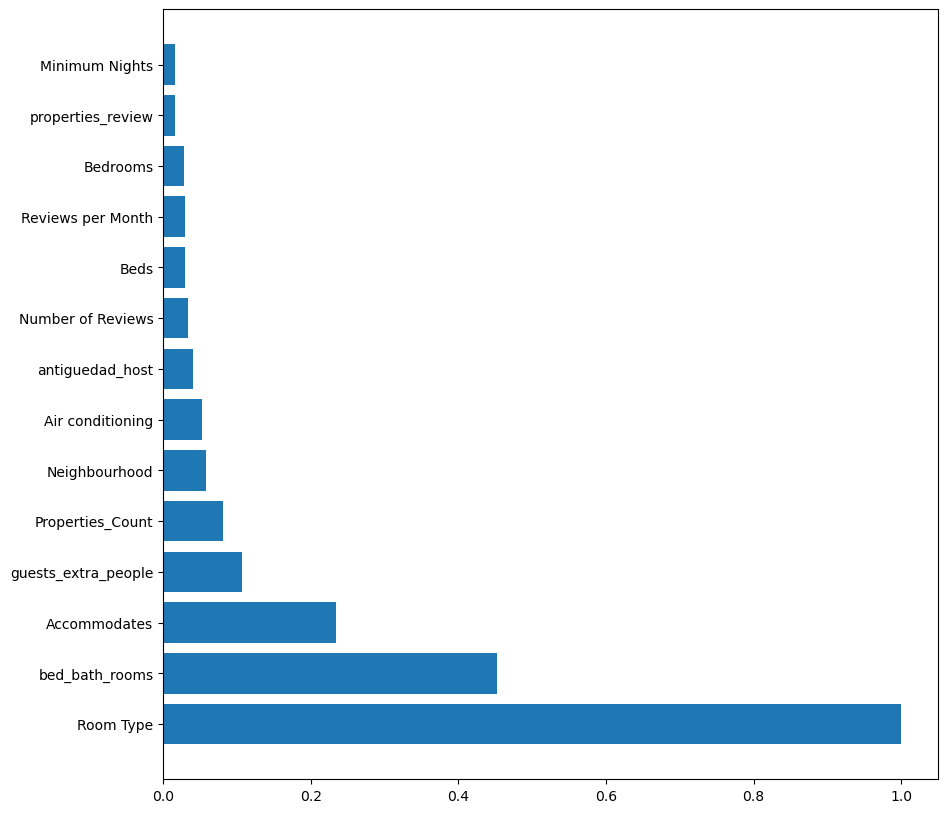

```python
importances = bt.feature_importances_
importances = importances / np.max(importances)

indices = np.argsort(importances)[::-1]

plt.figure(figsize=(10,10))
plt.barh(range(X_train.shape[1]), importances[indices])
plt.yticks(range(X_train.shape[1]), features[indices])
plt.show()
```

```python
# Ahora trabajaremos con XGBoost

from xgboost import XGBRegressor

Niterations = [100, 200, 500, 1000, 1500, 2000]
learningRate = [0.1, 0.05, 0.01]
maxDepth = 10
param_grid = {'n_estimators': Niterations, 'learning_rate': learningRate}

grid = GridSearchCV(XGBRegressor(random_state = 0, max_depth = maxDepth), param_grid = param_grid)
grid.fit(X_train, y_train)

print("best mean cross-validation score: {:.3f}".format(grid.best_score_))
print("best parameters: {}".format(grid.best_params_))
```

```
best mean cross-validation score: 0.656
best parameters: {'learning_rate': 0.01, 'n_estimators': 1000}
```

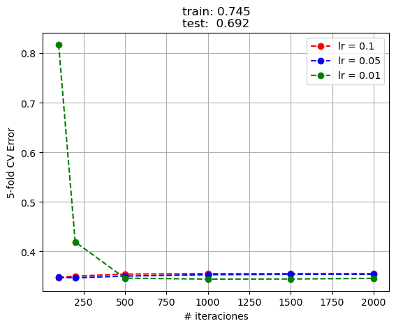

```python
# NeOptimo = 1000
# lrOptimo = 0.01
lrOptimo = grid.best_params_['learning_rate']
neOptimo = grid.best_params_['n_estimators']

# Vamos a bajar max_depth para controlar el overfitting evidente. Además vamos a regularizar L1 y L2
xgb = XGBRegressor(random_state = 0, max_depth = 4, learning_rate = lrOptimo, n_estimators = neOptimo,
                   reg_alpha = 0.6, reg_lambda = 0.6)
xgb.fit(X_train, y_train)

error = 1-grid.cv_results_['mean_test_score'].reshape(len(learningRate), len(Niterations))
colors = ['r','b','g','k','m']

for i, lr in enumerate(learningRate):
    plt.plot(Niterations, error[i,:],colors[i] + '--o', label = 'lr = %g'%lr)

plt.legend()
plt.xlabel('# iteraciones')
plt.ylabel('5-fold CV Error')
plt.title('train: %0.3f\ntest:  %0.3f'%(xgb.score(X_train,y_train),xgb.score(X_test,y_test)))
plt.grid()
plt.show()
```

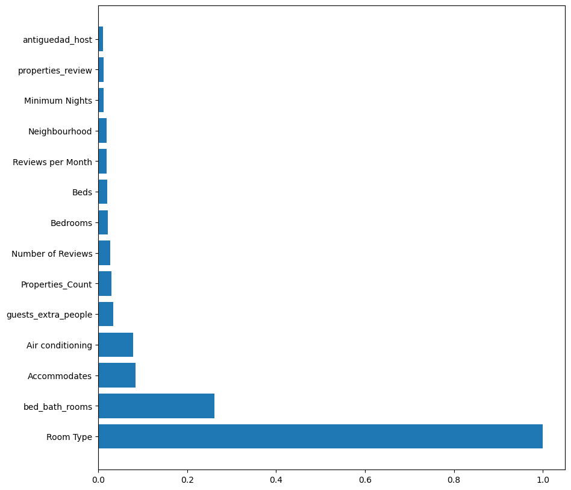

```python
importances = xgb.feature_importances_
importances = importances / np.max(importances)

indices = np.argsort(importances)[::-1]

plt.figure(figsize=(10,10))
plt.barh(range(X_train.shape[1]), importances[indices])
plt.yticks(range(X_train.shape[1]), features[indices])
plt.show()
```

```python
# Trabajamos ahora con LightGBM
#!pip install LightGBM
import lightgbm as lgb

Niterations = [100, 200, 300, 400, 500, 1000, 1500, 2000, 3000]
learningRate = [0.1, 0.05, 0.01, 0.001]
maxDepth = 10
param_grid = {'n_estimators': Niterations, 'learning_rate': learningRate}

grid = GridSearchCV(lgb.LGBMRegressor(random_state = 0, max_depth = maxDepth), param_grid = param_grid)
grid.fit(X_train, y_train)

print("best mean cross-validation score: {:.3f}".format(grid.best_score_))
print("best parameters: {}".format(grid.best_params_))
```

```
     ---------------------------------------- 1.0/1.0 MB 3.1 MB/s eta 0:00:00
best mean cross-validation score: 0.686
best parameters: {'learning_rate': 0.01, 'n_estimators': 1000}
```

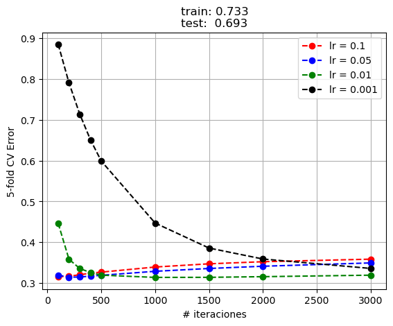

```python
# neOptimo = 1000
# lrOptimo = 0.01
lrOptimo = grid.best_params_['learning_rate']
neOptimo = grid.best_params_['n_estimators']

# Vamos a bajar algo max_depth ya que parece que hay algo de overfitting. También vamos a regularizar con los parámetros alpha y lambda
lgbm = lgb.LGBMRegressor(random_state = 0, max_depth = 4, learning_rate = lrOptimo, n_estimators = neOptimo,
                        reg_alpha = 0.5, reg_lambda = 0.5)
lgbm.fit(X_train, y_train)

# Ver si lo imprimo así
error = 1-grid.cv_results_['mean_test_score'].reshape(len(learningRate), len(Niterations))
colors = ['r','b','g','k','m']

for i, lr in enumerate(learningRate):
    plt.plot(Niterations, error[i,:],colors[i] + '--o', label = 'lr = %g'%lr)

plt.legend()
plt.xlabel('# iteraciones')
plt.ylabel('5-fold CV Error')
plt.title('train: %0.3f\ntest:  %0.3f'%(lgbm.score(X_train,y_train),lgbm.score(X_test,y_test)))
plt.grid()
plt.show()
```

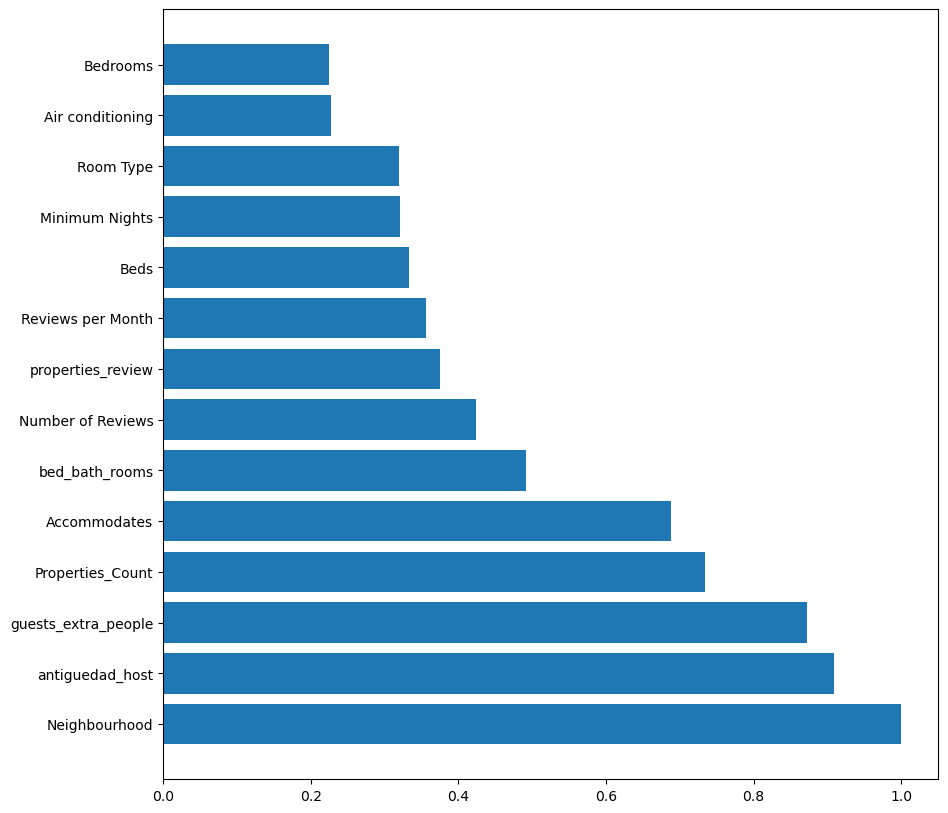

```python
importances = lgbm.feature_importances_
importances = importances / np.max(importances)

indices = np.argsort(importances)[::-1]

plt.figure(figsize=(10,10))
plt.barh(range(X_train.shape[1]), importances[indices])
plt.yticks(range(X_train.shape[1]), features[indices])
plt.show()
```

Cada uno de los diferentes modelos, nos han arrojado un peso similar en muchas de las variables pero ha habido diferencias importantes en otras, lo cual es llamativo y puede ser un indicativo de cómo trabaja cada algoritmo, lo que da pistas de cara a cómo y con qué trabajar en el futuro según el problema con el que nos encontremos. Por ejemplo, LightGBM da un coeficiente alto a un buen número de variables, mientras que XGBoost y los Boosted Trees están prácticamente descartando la gran mayoría y quedándose con un número reducido.

No es un resultado brillante. El aspecto donde deberíamos trabajar para obtener unos resultados mejores sería en el análisis exploratorio, revisando la utilidad o no de determinadas columnas (quizás alguna de las que descartamos podría tener valor, como es el caso de los metros cuadrados, pero apenas había en este dataset un 5% de valores no nulos, por lo que no podíamos hacer nada a ese respecto). Podríamos valorar incluir algunas columnas más que eliminamos, pero estaríamos perjudicando la interpretabilidad. Se tomó la decisión de eliminar algunas que eran dificilmente interpretables por esta razón. También podríamos valorar la relación entre algunas variables. Si bien ya se incluyeron algunas relaciones que han resultado tener bastante sentido (para según qué algoritmo), como por ejemplo la antigüedad del host con LightGBM (caso llamativo en comparación con XGBoost que no le da ninguna relevancia) o la cantidad de propiedades del host, podríamos revisar e incluir algunas relaciones nuevas.

Tambíen da la impresión, de que hasta determinados valores, en concreto los pisos que van de un costo del mínimo hasta los 75-80 euros la noche, la regresión lineal funciona bastante bien, pero después falla totalmente. Podríamos valorar la creación de un modelo propio para ese tipo de alquileres y seguramente tener unos resultado muy buenos, con un modelo extremadamente simple y trabajar con otros modelos más complejos teniendo en cuenta más características a partir de esos 75-80 euros, de forma que logremos unos resultados mucho más precisos, utilizando dos modelos diferenciados, para alquileres "económicos" y alquileres "caros". Si tuviera tiempo y la cantidad de datos necesarios (la gran mayoría de datos son para valores "económicos"), me gustaría probar este enfoque y desarrollar estos dos modelos diferenciados para comparar los resultados con los modelos que he entrenado.